# COSC5610 CMV Analysis

Noah Asaria, David Reddy, Eddie Chapman

```r
library(jsonlite)
library(lubridate)
library(SnowballC)
library(tidyverse)
library(topicmodels)
library(tm)
library(tidytext)
```

## Data import

Data is separated into two spreadsheets:

- `threads.csv`
- `comments.csv`

### Thread data

After importing, any threads that do not start with `CMV:` are dropped. These are moderator notes or other irrelevant threads.

We remove `CMV:` from the remaining thread titles. We also remove the default moderator note that is included at the bottom of most thread texts.

```r
threads <- read_csv("threads.csv", col_names = TRUE) %>%
  filter(str_starts(title, coll("CMV:"))) %>%
  mutate(title = str_replace(title, "CMV:", ""),
         text = str_replace(text, "\\*Hello, users of CMV\\! .* \\*Happy CMVing\\!\\*", ""),
         id = as.factor(id),
         timestamp = as.Date.POSIXct(timestamp),
         week = week(timestamp),
         year = year(timestamp),
         ups = as.integer(ups),
         downs = as.integer(downs))
```

### Comment data

Comment data contains the author, OP, thread, and timestamp of all threads.

We drop any comments that are posted by the thread’s OP, by the DeltaBot, or by a deleted account.

We also drop any comments correponding to irrelevant threads identified in the `threads` dataframe.

```r
comments <- read_csv('comments.csv', col_names = TRUE) %>%
  filter(author != op,
         author != 'DeltaBot',
         author != '[DELETED]') %>%
  mutate(id = as.factor(id),
         thread = as.factor(thread),
         timestamp = as.Date.POSIXct(timestamp)) %>%
  semi_join(threads, by = c("thread" = "id"))
```

## Summary statistics

Here we identify the total number of comments and unique commentors for each thread.

```r
users_per_thread <- comments %>%
  select(thread, author) %>%
  distinct() %>%
  group_by(thread) %>%
  count(name = 'n_users')

comments_per_thread <- comments %>%
  select(thread, id) %>%
  distinct() %>%
  group_by(thread) %>%
  count(name = 'n_comments')

threads <- threads %>%
  left_join(users_per_thread, by = c("id" = "thread")) %>%
  left_join(comments_per_thread, by = c("id" = "thread")) %>%
  mutate(comments_per_user = n_users / n_comments)

summary(threads)
```

```
##       id               title              author              text
##  Length:8345        Length:8345        Length:8345        Length:8345
##  Class :character   Class :character   Class :character   Class :character
##  Mode  :character   Mode  :character   Mode  :character   Mode  :character
##
##
##
##
##    timestamp               ups              downs        week
##  Min.   :2013-02-09   Min.   :   0.00   Min.   :0   Min.   : 1.00
##  1st Qu.:2014-06-03   1st Qu.:   3.00   1st Qu.:0   1st Qu.:15.00
##  Median :2014-09-04   Median :  10.00   Median :0   Median :23.00
##  Mean   :2014-09-15   Mean   :  55.01   Mean   :0   Mean   :25.33
##  3rd Qu.:2015-01-01   3rd Qu.:  30.00   3rd Qu.:0   3rd Qu.:36.00
##  Max.   :2015-05-08   Max.   :2990.00   Max.   :0   Max.   :53.00
##
##       year         n_users         n_comments      comments_per_user
##  Min.   :2013   Min.   :  1.00   Min.   :   1.00   Min.   :0.1528
##  1st Qu.:2014   1st Qu.: 10.00   1st Qu.:  16.00   1st Qu.:0.4310
##  Median :2014   Median : 17.00   Median :  32.00   Median :0.5476
##  Mean   :2014   Mean   : 26.79   Mean   :  57.58   Mean   :0.5728
##  3rd Qu.:2015   3rd Qu.: 29.00   3rd Qu.:  60.00   3rd Qu.:0.6923
##  Max.   :2015   Max.   :402.00   Max.   :1250.00   Max.   :1.0000
##                 NA's   :34       NA's   :34        NA's   :34
```

```r
summary(comments)
```

```
##           id               thread            op               author
##  t1_c8ccmp9:     1   t3_2pfo8x:  1250   Length:478522      Length:478522
##  t1_c8ccp2s:     1   t3_27a6jh:  1030   Class :character   Class :character
##  t1_c8cht3k:     1   t3_26gh41:  1002   Mode  :character   Mode  :character
##  t1_c8chwpo:     1   t3_289fle:   991
##  t1_c8clxup:     1   t3_2dx2pd:   982
##  t1_c8cnjjk:     1   t3_2qy21w:   945
##  (Other)   :478516   (Other)  :472322
##    timestamp
##  Min.   :2013-02-09
##  1st Qu.:2014-06-11
##  Median :2014-09-12
##  Mean   :2014-09-23
##  3rd Qu.:2015-01-06
##  Max.   :2015-05-09
##
```

## Sampling

(Temporary) we reduce the dataset to improve computation time.

Threads are selected which fall between the median and 3rd quartile measure of number of unique users, number of total comments, and upvotes.

This leaves us with 505 threads.

```r
popular_threads <- threads %>%
  filter(n_users >= 17, n_users <= 29) %>%
  filter(n_comments >= 32, n_comments <= 60) %>%
  filter(ups >= 10, ups <= 30)

summary(popular_threads)
```

```
##       id               title              author              text
##  Length:505         Length:505         Length:505         Length:505
##  Class :character   Class :character   Class :character   Class :character
##  Mode  :character   Mode  :character   Mode  :character   Mode  :character
##
##
##
##    timestamp               ups            downs        week
##  Min.   :2013-05-12   Min.   :10.00   Min.   :0   Min.   : 1.00
##  1st Qu.:2014-06-16   1st Qu.:13.00   1st Qu.:0   1st Qu.:14.00
##  Median :2014-09-14   Median :17.00   Median :0   Median :23.00
##  Mean   :2014-09-28   Mean   :17.42   Mean   :0   Mean   :24.76
##  3rd Qu.:2015-01-21   3rd Qu.:21.00   3rd Qu.:0   3rd Qu.:36.00
##  Max.   :2015-05-07   Max.   :30.00   Max.   :0   Max.   :53.00
##       year         n_users        n_comments    comments_per_user
##  Min.   :2013   Min.   :17.00   Min.   :32.00   Min.   :0.2833
##  1st Qu.:2014   1st Qu.:19.00   1st Qu.:37.00   1st Qu.:0.4490
##  Median :2014   Median :22.00   Median :43.00   Median :0.5128
##  Mean   :2014   Mean   :22.09   Mean   :43.43   Mean   :0.5207
##  3rd Qu.:2015   3rd Qu.:25.00   3rd Qu.:49.00   3rd Qu.:0.5882
##  Max.   :2015   Max.   :29.00   Max.   :60.00   Max.   :0.8438
```

```r
threads_per_week <- popular_threads %>%
  group_by(year, week) %>%
  count(name = "threads_per_week") %>%
  arrange(year, week)

summary(threads_per_week)
```

```
##       year           week       threads_per_week
##  Min.   :2013   Min.   : 1.00   Min.   : 1.000
##  1st Qu.:2014   1st Qu.:13.50   1st Qu.: 5.000
##  Median :2014   Median :23.00   Median : 8.000
##  Mean   :2014   Mean   :25.28   Mean   : 7.537
##  3rd Qu.:2015   3rd Qu.:38.50   3rd Qu.:10.000
##  Max.   :2015   Max.   :53.00   Max.   :18.000
```

```r
popular_threads <- popular_threads %>%
  left_join(threads_per_week)

popular_threads
```

| id | title | author | text | timestamp | ups | downs | week | year | n_users | n_comments | comments_per_user | threads_per_week |
| --- | --- | --- | --- | --- | --- | --- | --- | --- | --- | --- | --- | --- |
| t3_2rpcgr | It is ok to hate a religion so long as you do not hate its followers | debatingaccount | It seems to me that it is entirely justified to believe that a set of beliefs are wrong and to desire to see less people follow that belief. If you disagree with certain parts of a religion and believ… | 2015-01-08 | 30 | 0 | 2 | 2015 | 24 | 59 | 0.4067797 | 6 |
| t3_2rjau6 | Whole Brain Emulation is clearly the way the Singularity is coming. | SevenAugust | [Wikipedia on the (idea of) the Singularity](http://en.wikipedia.org/wiki/Technological_singularity)\n\n[Wikipedia on (the idea of) whole brain emulation](http://en.wikipedia.org/wiki/Whole_brain_emul… | 2015-01-06 | 17 | 0 | 1 | 2015 | 22 | 49 | 0.4489796 | 9 |
| t3_2rh0xo | I think that drone strikes and other similar types of operations like with bin Laden are futile and illegal | CaptainNapoleon | The US military is taking justice into its own hands by conducting extrajudicial killings of terrorists. Yes they have committed horrendous crimes against the United States and killed scores of innoce… | 2015-01-06 | 26 | 0 | 1 | 2015 | 20 | 34 | 0.5882353 | 9 |
| t3_2rcrkd | Veganism and vegetarianism are not the best way to improve farm animal welfare | Helicase21 | Title is mostly to get attention, and I'm working from a specific set of assumptions. My argument is as follows:\n\n1) The chances of the entire world adopting a vegan/vegetarian diet are slim to none… | 2015-01-05 | 22 | 0 | 1 | 2015 | 27 | 49 | 0.5510204 | 9 |
| t3_2r7f0g | Colonel Quaritch from "Avatar" was right. | Curious_Miner | Recently, I stumbled upon [this](http://i.imgur.com/MEgVf.jpg) after a discussion of Avatar with a friend. [ (Not from the movie, but from here) ](http://tvtropes.org/pmwiki/posts.php?discussion=sa7rm… | 2015-01-03 | 25 | 0 | 1 | 2015 | 21 | 44 | 0.4772727 | 9 |
| t3_2r4fa8 | Universities that receive public funding should be responsible for placing their graduating students in relevant careers | BrawndoTTM | We spend an absolutely ludicrous amount of public money on education, yet the government rarely demands a return on this investment. IMO this is an unconscionable use of public funds. In addition to t… | 2015-01-02 | 21 | 0 | 1 | 2015 | 28 | 47 | 0.5957447 | 9 |
| t3_2r3xug | Gun violence, education reform, concussions in American football, the European far right, and the Israel-Palestine conflict cannot be resolved without fixing economic inequality. | selfhatingyank | In recent years, a number of studies have shown that the US in particular has the lowest income equality, among the lowest income mobility, and among the highest indexes of social problems in the deve… | 2015-01-02 | 19 | 0 | 1 | 2015 | 27 | 48 | 0.5625000 | 9 |
| t3_2r1ntj | The idea of "Buy local" or "Buy American" is primarily grounded in selfishness. | fsd987 | Recently there has been a shift from the industrial globalized system of goods (food, handmade items, clothing, etc) to more alternative systems like farmers markets, local businesses, and "buying Ame… | 2015-01-01 | 18 | 0 | 1 | 2015 | 26 | 40 | 0.6500000 | 9 |
| t3_2qzupz | I believe that same sex marriage has distracted LGBT people from more important issues | EwanWhoseArmy | From my point of view at least alot of LGBT people in the UK have seemed to accept that "the battle is won" and now we have same sex marriage we are all equal, all happy and all of that. In Fact where… | 2015-01-01 | 29 | 0 | 1 | 2015 | 22 | 43 | 0.5116279 | 9 |
| t3_2qzlr5 | As we change from 2014 to 2015 — I think the acronyms B.C.E. and C.E. which are used to supersede B.C. and A.D. are antihistorical, pretentious euphemisms with no place in the scientific and academic … | openforum2011 | I thought it appropriate timing to post this CMV as we change from the year 2014 AD (or is that "CE"?) to 2015 in the near-universal Gregorian calendar across each timezone of the world.\n\nAs you may… | 2015-01-01 | 20 | 0 | 1 | 2015 | 22 | 33 | 0.6666667 | 9 |

[output cut: 495 more lines]

```r
sample <- popular_threads %>%
  filter(threads_per_week >= 5, threads_per_week <= 10)

sample
```

| id | title | author | text | timestamp | ups | downs | week | year | n_users | n_comments | comments_per_user | threads_per_week |
| --- | --- | --- | --- | --- | --- | --- | --- | --- | --- | --- | --- | --- |
| t3_2rpcgr | It is ok to hate a religion so long as you do not hate its followers | debatingaccount | It seems to me that it is entirely justified to believe that a set of beliefs are wrong and to desire to see less people follow that belief. If you disagree with certain parts of a religion and believ… | 2015-01-08 | 30 | 0 | 2 | 2015 | 24 | 59 | 0.4067797 | 6 |
| t3_2rjau6 | Whole Brain Emulation is clearly the way the Singularity is coming. | SevenAugust | [Wikipedia on the (idea of) the Singularity](http://en.wikipedia.org/wiki/Technological_singularity)\n\n[Wikipedia on (the idea of) whole brain emulation](http://en.wikipedia.org/wiki/Whole_brain_emul… | 2015-01-06 | 17 | 0 | 1 | 2015 | 22 | 49 | 0.4489796 | 9 |
| t3_2rh0xo | I think that drone strikes and other similar types of operations like with bin Laden are futile and illegal | CaptainNapoleon | The US military is taking justice into its own hands by conducting extrajudicial killings of terrorists. Yes they have committed horrendous crimes against the United States and killed scores of innoce… | 2015-01-06 | 26 | 0 | 1 | 2015 | 20 | 34 | 0.5882353 | 9 |
| t3_2rcrkd | Veganism and vegetarianism are not the best way to improve farm animal welfare | Helicase21 | Title is mostly to get attention, and I'm working from a specific set of assumptions. My argument is as follows:\n\n1) The chances of the entire world adopting a vegan/vegetarian diet are slim to none… | 2015-01-05 | 22 | 0 | 1 | 2015 | 27 | 49 | 0.5510204 | 9 |
| t3_2r7f0g | Colonel Quaritch from "Avatar" was right. | Curious_Miner | Recently, I stumbled upon [this](http://i.imgur.com/MEgVf.jpg) after a discussion of Avatar with a friend. [ (Not from the movie, but from here) ](http://tvtropes.org/pmwiki/posts.php?discussion=sa7rm… | 2015-01-03 | 25 | 0 | 1 | 2015 | 21 | 44 | 0.4772727 | 9 |
| t3_2r4fa8 | Universities that receive public funding should be responsible for placing their graduating students in relevant careers | BrawndoTTM | We spend an absolutely ludicrous amount of public money on education, yet the government rarely demands a return on this investment. IMO this is an unconscionable use of public funds. In addition to t… | 2015-01-02 | 21 | 0 | 1 | 2015 | 28 | 47 | 0.5957447 | 9 |
| t3_2r3xug | Gun violence, education reform, concussions in American football, the European far right, and the Israel-Palestine conflict cannot be resolved without fixing economic inequality. | selfhatingyank | In recent years, a number of studies have shown that the US in particular has the lowest income equality, among the lowest income mobility, and among the highest indexes of social problems in the deve… | 2015-01-02 | 19 | 0 | 1 | 2015 | 27 | 48 | 0.5625000 | 9 |
| t3_2r1ntj | The idea of "Buy local" or "Buy American" is primarily grounded in selfishness. | fsd987 | Recently there has been a shift from the industrial globalized system of goods (food, handmade items, clothing, etc) to more alternative systems like farmers markets, local businesses, and "buying Ame… | 2015-01-01 | 18 | 0 | 1 | 2015 | 26 | 40 | 0.6500000 | 9 |
| t3_2qzupz | I believe that same sex marriage has distracted LGBT people from more important issues | EwanWhoseArmy | From my point of view at least alot of LGBT people in the UK have seemed to accept that "the battle is won" and now we have same sex marriage we are all equal, all happy and all of that. In Fact where… | 2015-01-01 | 29 | 0 | 1 | 2015 | 22 | 43 | 0.5116279 | 9 |
| t3_2qzlr5 | As we change from 2014 to 2015 — I think the acronyms B.C.E. and C.E. which are used to supersede B.C. and A.D. are antihistorical, pretentious euphemisms with no place in the scientific and academic … | openforum2011 | I thought it appropriate timing to post this CMV as we change from the year 2014 AD (or is that "CE"?) to 2015 in the near-universal Gregorian calendar across each timezone of the world.\n\nAs you may… | 2015-01-01 | 20 | 0 | 1 | 2015 | 22 | 33 | 0.6666667 | 9 |

[output cut: 293 more lines]

```r
summary(sample)
```

```
##       id               title              author              text
##  Length:303         Length:303         Length:303         Length:303
##  Class :character   Class :character   Class :character   Class :character
##  Mode  :character   Mode  :character   Mode  :character   Mode  :character
##
##
##
##    timestamp               ups            downs        week
##  Min.   :2014-04-02   Min.   :10.00   Min.   :0   Min.   : 1.00
##  1st Qu.:2014-06-28   1st Qu.:13.00   1st Qu.:0   1st Qu.:13.00
##  Median :2014-10-20   Median :17.00   Median :0   Median :20.00
##  Mean   :2014-10-15   Mean   :17.74   Mean   :0   Mean   :23.46
##  3rd Qu.:2015-02-02   3rd Qu.:21.00   3rd Qu.:0   3rd Qu.:35.00
##  Max.   :2015-04-29   Max.   :30.00   Max.   :0   Max.   :52.00
##       year         n_users        n_comments   comments_per_user
##  Min.   :2014   Min.   :17.00   Min.   :32.0   Min.   :0.2833
##  1st Qu.:2014   1st Qu.:19.00   1st Qu.:37.0   1st Qu.:0.4500
##  Median :2014   Median :22.00   Median :43.0   Median :0.5135
##  Mean   :2014   Mean   :22.21   Mean   :43.7   Mean   :0.5198
##  3rd Qu.:2015   3rd Qu.:25.00   3rd Qu.:49.0   3rd Qu.:0.5802
##  Max.   :2015   Max.   :29.00   Max.   :60.0   Max.   :0.8438
##  threads_per_week
##  Min.   : 5.000
##  1st Qu.: 6.000
##  Median : 9.000
##  Mean   : 8.188
##  3rd Qu.:10.000
##  Max.   :10.000
```

## Tokenizing

Our text cleaning function removes URLs, symbols and formatting, and a few common reddit terms.

```r
clean_text <- function(text) {
  str_replace_all(
    text,
    c("https?:\\/\\/.*[\r\n]*" = " ",                       # URLs
      "_____|\\\n|&amp;|#x200B;|nbsp|&gt;" = " ",           # Symbols and formatting
      "'s" = " ")
  )
}
```

```r
my_stop_words <- c(
  "edit", "reddit", "cmv", "change", "view", "people", "person", "post",
  "vote", "delta", "score", "comment", "debate", "life", "feel", "time"
)
```

```r
tokens <- sample %>%
  mutate(text = paste(title, text)) %>%
  mutate(text = clean_text(text)) %>%
  select(id, text) %>%
  unnest_tokens(word, text) %>%
  filter(str_detect(word, "[a-z]$")) %>%
  filter(!word %in% my_stop_words) %>%
  filter(!word %in% stop_words$word) %>%
  filter(length(word) > 2)

dictionary <- tokens %>%
  select(word) %>%
  unique() %>%
  arrange(word)

dictionary <- as.vector(dictionary$word)

tokens <- tokens %>%
  mutate(word = wordStem(word, language = "english")) %>%
  mutate(word = stemCompletion(word, dictionary = dictionary)) %>%
  select(id, word) %>%
  filter(word != "") %>%
  count(id, word, sort = TRUE) %>%
  ungroup()

tokens
```

| id | word | n |
| --- | --- | --- |
| t3_25l3gr | word | 21 |
| t3_29koa9 | football | 21 |
| t3_29koa9 | soccer | 19 |
| t3_2yrgi3 | women | 18 |
| t3_25ikk0 | car | 17 |
| t3_25ikk0 | insurance | 17 |
| t3_26d20x | language | 17 |
| t3_2a6nk5 | animal | 17 |
| t3_2p6y53 | dog | 17 |
| t3_2pkcvf | immigrant | 17 |

[output cut: 9990 more lines]

```r
cmv_dtm <- tokens %>%
  cast_dtm(id, word, n)

cmv_lda <- cmv_dtm %>%
  LDA(k = 25)

cmv_topics <- tidy(cmv_lda, matrix = "beta")

top_terms <- cmv_topics %>%
  group_by(topic) %>%
  top_n(5, beta) %>%
  ungroup() %>%
  arrange(topic, -beta)

top_terms
```

| topic | term | beta |
| --- | --- | --- |
| 1 | militarization | 0.025248000 |
| 1 | women | 0.025151988 |
| 1 | war | 0.023847740 |
| 1 | kill | 0.015570823 |
| 1 | crime | 0.014276278 |
| 2 | moral | 0.028026902 |
| 2 | dog | 0.026024217 |
| 2 | science | 0.017998366 |
| 2 | health | 0.016972316 |
| 2 | medicine | 0.011314877 |

[output cut: 115 more lines]

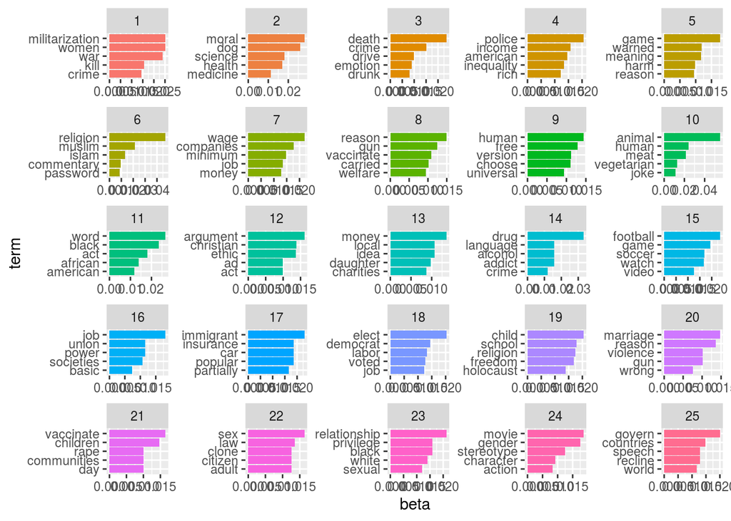

```r
top_terms %>%
  mutate(term = reorder_within(term, beta, topic)) %>%
  ggplot(aes(term, beta, fill = factor(topic))) +
  geom_col(show.legend = FALSE) +
  facet_wrap(~ topic, scales = "free") +
  coord_flip() +
  scale_x_reordered()
```

```r
thread_topics <- tidy(cmv_lda, matrix = "gamma")

topic_threads <- thread_topics %>%
  group_by(topic) %>%
  arrange(topic, desc(gamma)) %>%
  top_n(3, gamma) %>%
  ungroup() %>%
  left_join(sample, by = c("document" = "id")) %>%
  select(topic, title)

topic_threads
```

| topic | title |
| --- | --- |
| 1 | Women should not serve in most military functions. |
| 1 | Japan has not sufficiently apologized for the war crimes of WWII |
| 1 | Democracy cannot be sustained, and will soon fail. |
| 2 | I think moral laws can be established by logic &amp; science and would be preferable than those currently established by faith and cultural norms. |
| 2 | Buying / breeding pedigree dogs is antiquated and harmful. |
| 2 | A National ID Card is a Good Idea |
| 3 | I'm living my life like a robot and think emotion is a flaw of humanity. |
| 3 | Gender shouldn't matter when physically defending oneself. |
| 3 | Crimes should not be treated as more severe merely because they resulted in deaths |
| 4 | Gun violence, education reform, concussions in American football, the European far right, and the Israel-Palestine conflict cannot be resolved without fixing economic inequality. |

[output cut: 65 more lines]